# Practical machine learning course project

Sergey Kolchin

18/04/2019

## The data

```r
# read.csv incorrectly determines column types containing only NAs
training <- read.csv("pml-training.csv", colClasses = cc)
testing <- read.csv("pml-testing.csv", colClasses = cc)
```

The project goal is to analyze data from accelerometers placed on the belt, forearm, arm, and dumbell provided by 6 participants doing some kinds of physical activity and predict the activity class using this data.

Two datasets with training and testing data were loaded from the course’ [description page](https://www.coursera.org/learn/practical-machine-learning/supplement/PvInj/course-project-instructions-read-first).

The datasets contain 160 variables. Training dataset contains 19622 observations, while testing dataset contains 20 observations.

Additional information on the datasets can be obtained [here](http://groupware.les.inf.puc-rio.br/har#weight_lifting_exercises).

## Feature selection

The outcome of the prediction is `classe` variable, which holds a classified result of the exercise. Class A corresponds to the specified execution, while the other 4 classes correspond to common mistakes.

A histogram of classes distribution in the training dataset is provided below.

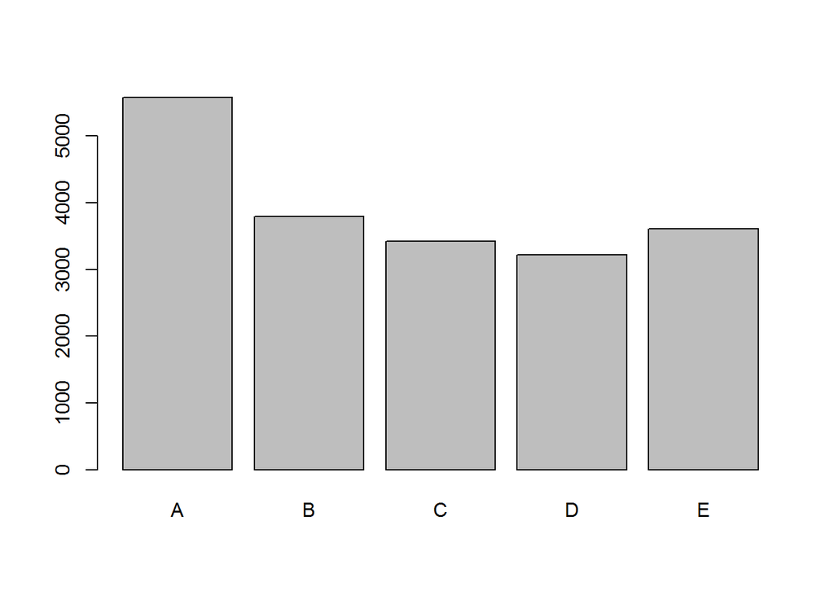

```r
plot(training$classe)
```

Let’s review other variables in the dataset.

There are some technical attributes indicating a person or time when the execution was performed. They need to be removed.

```r
valid_df <- subset(training,
            select = c(
              -X, -user_name, -raw_timestamp_part_1,
              -raw_timestamp_part_2, -cvtd_timestamp, -new_window,
              -num_window))
```

Near zero covariates can also to be removed.

```r
nzv <- nearZeroVar(valid_df)
valid_df <- valid_df[, -nzv]
```

There are several variables which contain mostly NA values. They would not provide any value in modeling, so they should also be removed.

```r
nna <- sapply(valid_df, function(x) mean(is.na(x))) > 0.95
valid_df <- valid_df[, nna == FALSE]
```

Now, split the dataset onto training and testing samples. The training dataset will be used for modeling, while the testing one - for model verification.

```r
inTrain <- createDataPartition(valid_df$classe, p = 0.75, list = FALSE)
train_df <- valid_df[inTrain, ]
test_df <- valid_df[-inTrain, ]
```

Below is a feature plot of the training dataset.

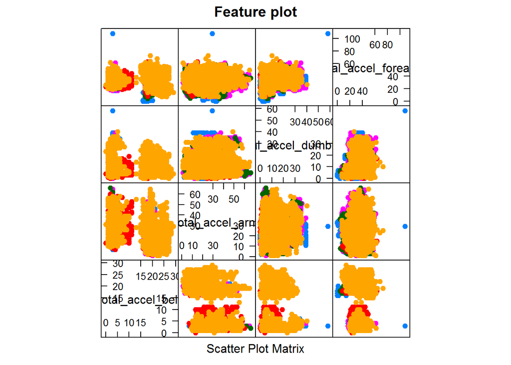

```r
total_cols <- which(grepl("^total", colnames(train_df), ignore.case = F))

train_features <- train_df[, total_cols]

featurePlot(x = train_features, y = train_df$classe, pch = 19, main = "Feature plot", plot = "pairs")
```

The remaining dataset contains 53 variables, including the outcome variable.

In order to reduce number of features, the PCA is applied.

```r
pca_result <- preProcess(train_df[,-53], method="pca")
train_pca_df <- predict(pca_result, train_df)
pca_result
```

```
## Created from 14718 samples and 52 variables
##
## Pre-processing:
##   - centered (52)
##   - ignored (0)
##   - principal component signal extraction (52)
##   - scaled (52)
##
## PCA needed 25 components to capture 95 percent of the variance
```

After applying the PCA, number of predictors has decreased to 25.

## Modeling

Traning is performed on PCA results.

```r
cl <- makePSOCKcluster(3)
registerDoParallel(cl)

m_rf <- train(classe ~ .,
              data = train_pca_df,
              method = "rf",
              metric = "Accuracy",
              trainControl = trainControl(
                method="repeatedcv",
                number=4,
                repeats=3,
                allowParallel = TRUE)
)
stopCluster(cl)
m_rf
```

```
## Random Forest
##
## 14718 samples
##    25 predictor
##     5 classes: 'A', 'B', 'C', 'D', 'E'
##
## No pre-processing
## Resampling: Bootstrapped (25 reps)
## Summary of sample sizes: 14718, 14718, 14718, 14718, 14718, 14718, ...
## Resampling results across tuning parameters:
##
##   mtry  Accuracy   Kappa
##    2    0.9651053  0.9558459
##   13    0.9593049  0.9485147
##   25    0.9476007  0.9337043
##
## Accuracy was used to select the optimal model using the largest value.
## The final value used for the model was mtry = 2.
```

```r
m_rf$finalModel
```

```
##
## Call:
##  randomForest(x = x, y = y, mtry = param$mtry, trainControl = ..1)
##                Type of random forest: classification
##                      Number of trees: 500
## No. of variables tried at each split: 2
##
##         OOB estimate of  error rate: 2.2%
## Confusion matrix:
##      A    B    C    D    E class.error
## A 4158    7   13    4    3 0.006451613
## B   47 2766   30    0    5 0.028792135
## C    5   30 2506   25    1 0.023763148
## D    7    2   88 2311    4 0.041873964
## E    1   15   19   18 2653 0.019586105
```

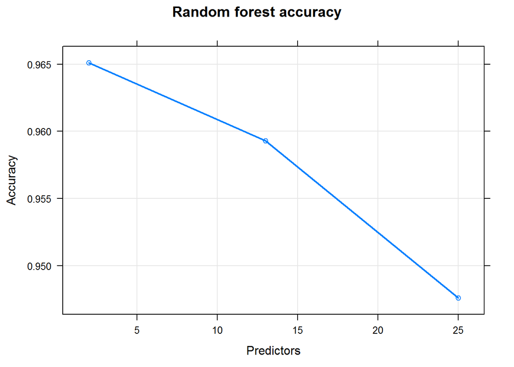

```r
plot(m_rf, log = "y",
     lwd = 2, main = "Random forest accuracy", xlab = "Predictors",
     ylab = "Accuracy")
```

```r
m <- m_rf$bestTune$mtry
insample_error <- 1 - m_rf$results[m,]$Accuracy
insample_error
```

```
## [1] 0.04069513
```

Out-of-sample error can be calculated by applying the model to the testing dataset and calculating proportion of successfull predictions.

A PCA-adapted version of the testing dataset has to be used.

```r
test_pca_df <- predict(pca_result, newdata = test_df)
test_pred <- predict(m_rf, newdata = test_pca_df)

oosample_accuracy <- sum(test_pred == test_pca_df$classe) / length(test_pred)

oosample_error <- 1 - oosample_accuracy
oosample_error
```

```
## [1] 0.02304241
```

## Prediction

Apply the model to the testing dataset provided by the course. A PCA-adapted version of the dataset has to be used.

```r
testing_pca_df <- predict(pca_result, newdata = testing)
testing_pred <- predict(m_rf, newdata = testing_pca_df)
testing_pred
```

```
##  [1] B A C A A E D B A A A C B A E E A B B B
## Levels: A B C D E
```